# OCN683_Distributions_HW4

## *Task 6*

Calculate the mean and variance of the counts. Also calculate what the variance would be if the counts were poisson-distributed. How does it differ from the observed data? Why might that be?

```r
#Calculating the mean and variance of the yellow tang
tangstats <- tang %>%
  summarise(
    mean = mean(count), #Mean = 5.0
    variance = sd(count),#Variance = 6.0
    PoissonVariance = mean(count) #Poisson Variance = observed mean = 5.0
  )
tangstats
```

```
##       mean variance PoissonVariance
## 1 5.026948 5.997327        5.026948
```

## **Task 7**

(7 – 4 points) Simulate five sets of random draws from the poisson distribution with the appropriate mean and variance (using the function rpois()). Plot histograms of the results, and report the means and variances of the simulated data. Verbally compare these distributions to the observed distribution.

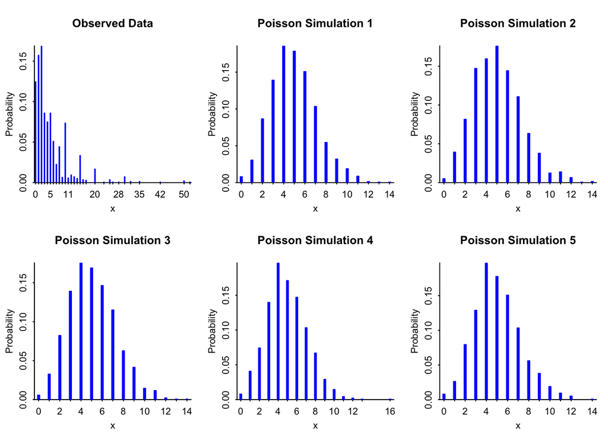

```r
# Load required package
set.seed(123)  # Set seed for reproducibility

# Define parameters
obs_mean <- 5  # Observed mean
num_obs <- length(tang$count)  # Number of observations in the dataset
n_simulations <- 5  # Number of simulations

# Create empty lists to store results
simulated_data <- list()
simulated_means <- numeric(n_simulations)
simulated_variances <- numeric(n_simulations)

# Set up plot area for 6 histograms
par(mfrow = c(2, 3))

# Plot histogram of observed data first
discrete.histogram(tang$count, col = "red", main = "Observed Data", freq = FALSE)

# Generate 5 sets of Poisson-distributed counts
for (i in 1:n_simulations) {
  # Simulate Poisson-distributed counts
  simulated_data[[i]] <- rpois(num_obs, lambda = obs_mean)

  # Compute mean and variance for the simulated dataset
  simulated_means[i] <- mean(simulated_data[[i]])
  simulated_variances[i] <- sd(simulated_data[[i]])

  # Plot histogram of simulated data
  discrete.histogram(simulated_data[[i]], col = "skyblue",
                     main = paste("Poisson Simulation", i), freq = FALSE)
}
```

```r
# Print observed mean and variance
mean(tang$count)
```

```
## [1] 5.026948
```

```r
simulated_means
```

```
## [1] 4.932993 5.035688 5.040058 4.897305 5.032775
```

```r
sd(tang$count)
```

```
## [1] 5.997327
```

```r
simulated_variances
```

```
## [1] 2.178251 2.301801 2.230650 2.159547 2.201829
```